# How was Trump’s proposed border wall discussed in his 2019 tweets?

Text Analysis Project Showcase · November 3, 2026

Author

Maricia Marquez · POLS 4130 · Fall 2026

## Research question

How did Donald Trump discuss the proposed U.S.–Mexico border wall in his 2019 tweets, and how did the sentiment and recurring themes of wall-related tweets compare with his broader Twitter communication?

### Data

This project analyzes **4,469 tweets** posted by Donald Trump between January 1 and December 31, 2019.

The dataset (`trump_tweets_2019.csv`) contains one tweet per observation.

Tweets were classified as wall-related if their text contained at least one of the following terms or phrases: “wall,” “barrier,” “fence,” “border security,” “southern border,” “caravan,” or “shutdown.”

- **237** wall-related tweets (5.3%)
- **4,232** other tweets (94.7%)

### Methods

**Sentiment analysis:** I used the Bing Liu sentiment dictionary, which assigns positive polarity (+1) and negative polarity (−1) to matched words. I applied a two-word negation rule to account for negators preceding sentiment-bearing words. I calculated sentiment scores across entire tweets and within a four-word target window surrounding references to “wall.”

**Topic modeling:** I used Latent Dirichlet Allocation (LDA) to identify recurring themes across the 2019 corpus. Tweets were tokenized, converted to lemmas, and stripped of SMART stopwords and selected additional terms. I selected four topics (k = 4) and interpreted them using prominent keywords and representative tweets.

The document-term matrix retained **4,434 tweets**. Thirty-five tweets with no retained words were excluded from topic modeling.

### Word frequency

The most frequently used terms provide an overview of recurring language in Trump’s 2019 tweets.

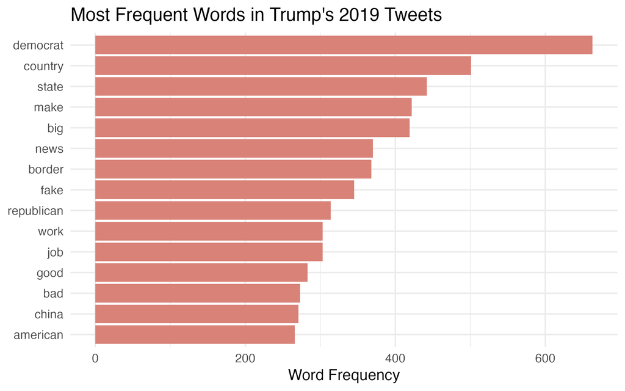

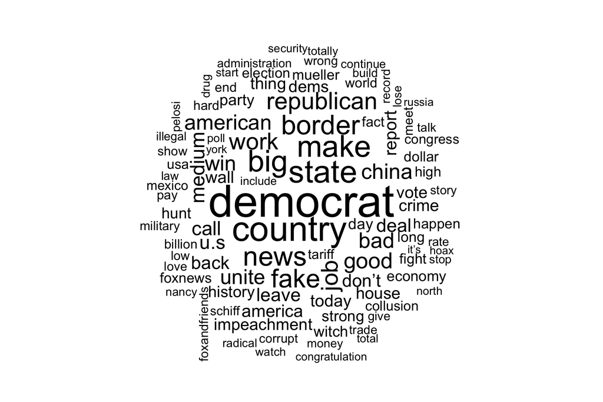

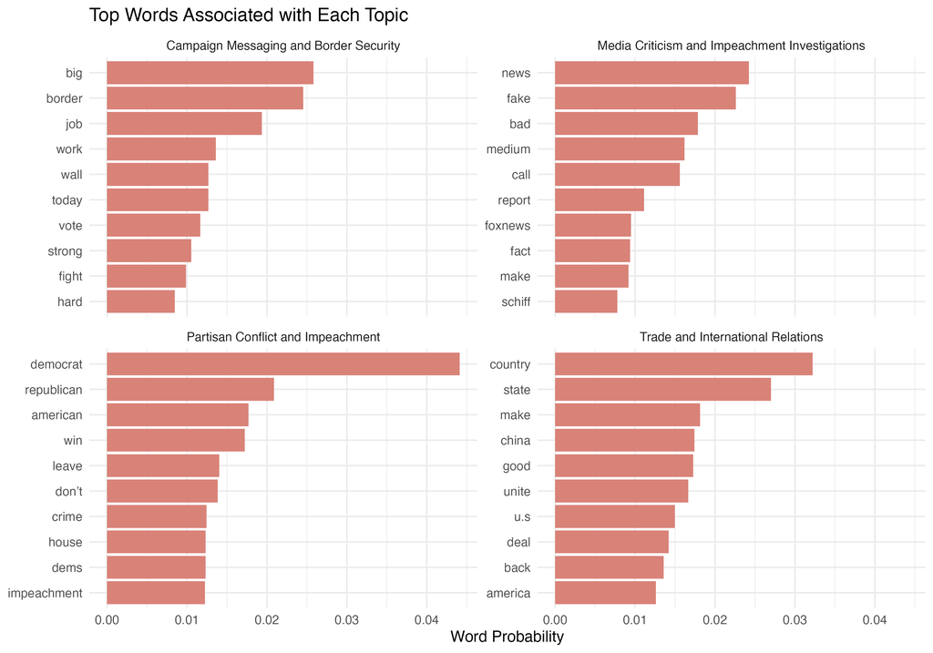

*The top words for each of the four estimated topics, extracted from the fitted LDA model.*

## Sentiment findings

Wall-related tweets exhibited more negative dictionary sentiment than other tweets.

Using the negation-adjusted measure, wall-related tweets had an average sentiment score of **−0.203**, compared with **+0.328** for other tweets.

This difference indicates that wall-related tweets contained a more negative balance of sentiment-bearing words. However, dictionary-based sentiment measures word-level polarity, not Trump’s overall position toward the border wall.

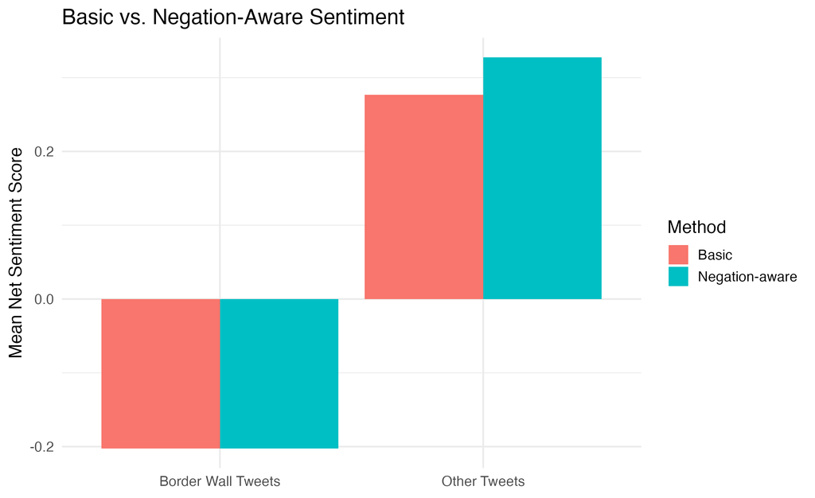

*Mean negation-adjusted Bing Liu sentiment score per tweet. Negative scores indicate more negative than positive matched words; they do not necessarily indicate opposition to the wall.*

### Basic sentiment comparison

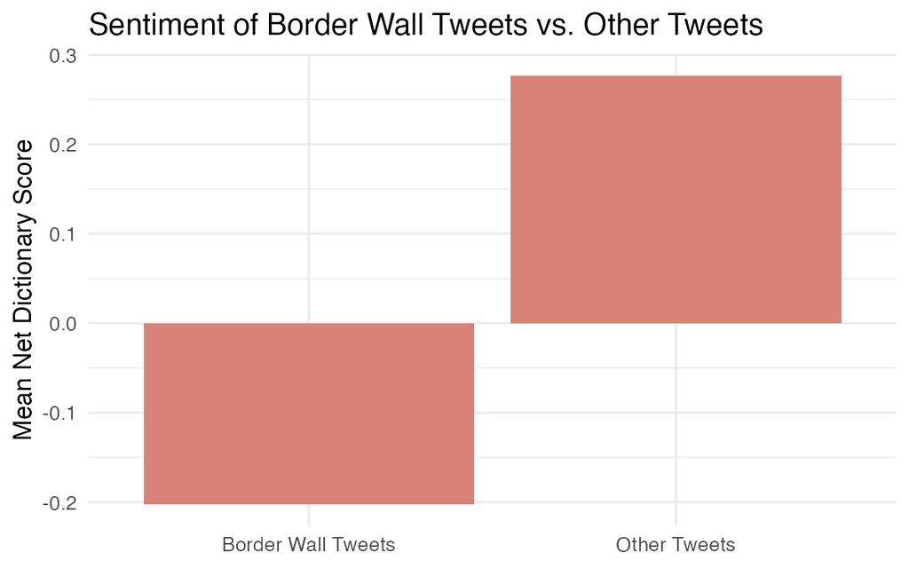

*Mean basic dictionary sentiment scores by tweet category, before applying the negation adjustment.*

### Sentiment surrounding “wall”

Among wall-related tweets with a target-window match, the average sentiment score was **−0.0295** across **81 matches**. No other-group tweets had a target-window match.

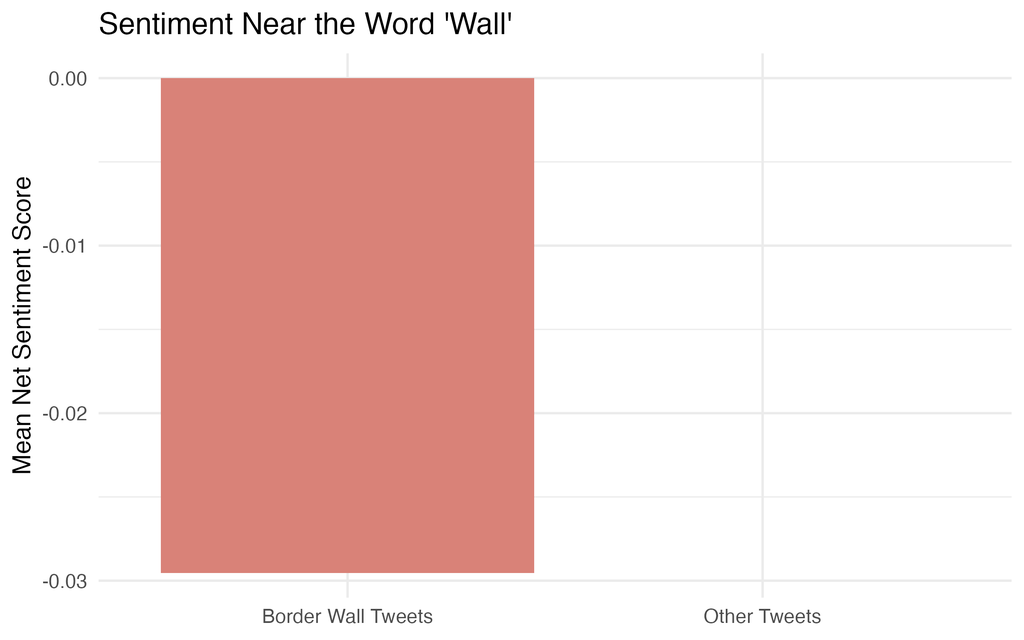

This score was close to 0, suggesting that negative sentiment across border-related tweets was not necessarily concentrated near explicit references to the word “wall.”

### Examining the original tweets

### Sentiment example — Tweet 112

> “The damage done to our Country from a badly broken Border - Drugs, Crime and so much that is bad - is far greater than a Shutdown…”

Tweet 112 received a net sentiment score of **−5** because the dictionary identified five negative words: *damage, badly, broken, crime,* and *bad*.

Trump used this negative language to characterize border conditions and argue for addressing the situation.

This illustrates the difference between negative vocabulary and the overall political message of a tweet.

### Limitations

**Sentiment:** Dictionary-based analysis cannot reliably identify sarcasm, complex rhetoric, context, or the target of a statement. Negative language may describe border conditions rather than express opposition to a border-wall policy. Dictionary coverage was limited: 8.17% of words in wall-related tweets and 11.5% of words in other tweets matched the sentiment dictionary. Target-window results were based on 81 matches.

**Topics:** LDA identifies patterns of word co-occurrence rather than objectively defined subjects. Tweets can address multiple themes, and topic labels require researcher interpretation. Results also depend on preprocessing decisions and the selected number of topics (k = 4). Differences in average topic proportions are descriptive and were not tested for statistical significance.

## Topic findings

The LDA model identified four recurring themes:

1. **Foreign Policy & National Interests**
2. **Partisan Politics & Elections**
3. **Border Security & Economic Promises**
4. **Media Criticism & Fake News**

Wall-related tweets had a higher average proportion of Topic 3 (**Border Security & Economic Promises**) than other tweets: **30.1% compared with 24.6%**.

The other three topics were less represented in the wall-related group.

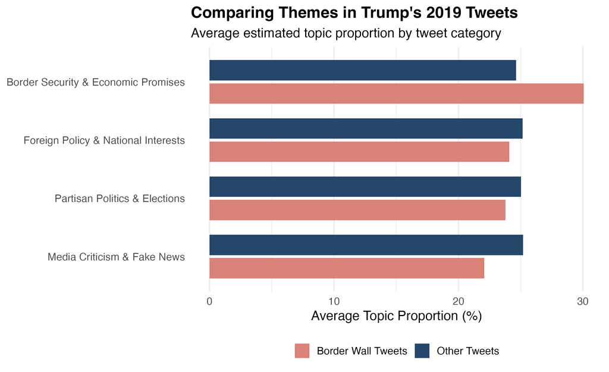

*Average estimated topic proportions across modeled documents.*

### Overall topic proportions

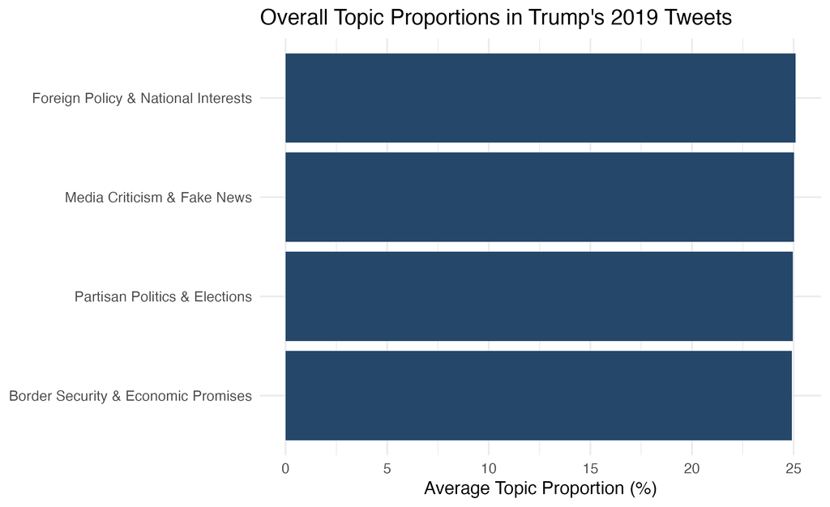

### Topic proportions in example tweets

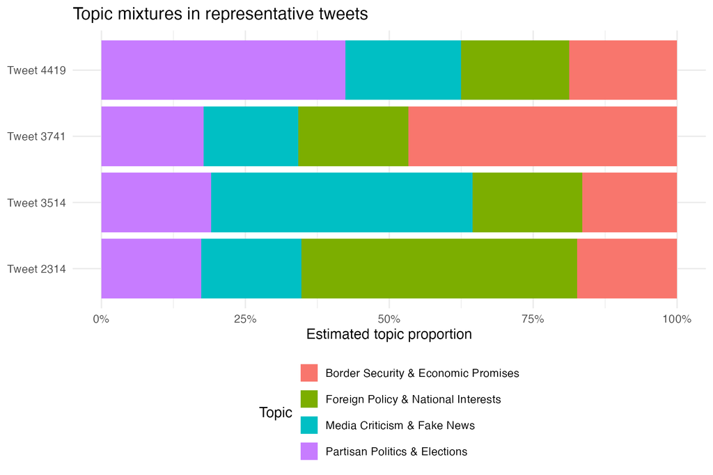

Each bar shows all four topic weights for a representative tweet.

### Sentiment by topic

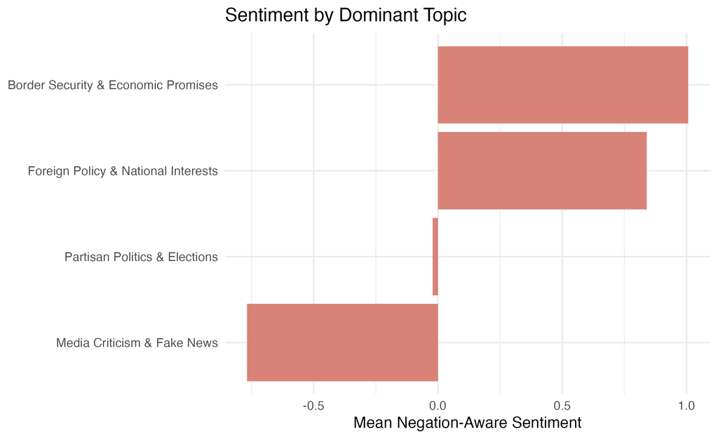

### Answer to the research question

Trump’s wall-related tweets differed from his broader 2019 communication in both sentiment vocabulary and thematic emphasis. Wall-related tweets had a more negative average dictionary sentiment score, while topic modeling showed a greater emphasis on border security and economic promises.

Together, these findings suggest that Trump’s border-related messaging frequently framed the issue through negative descriptions of border conditions and arguments about security and economic interests.

**Sources:**

- Trump, Donald J. (2019). *2019 Twitter corpus*. Supplied course dataset, `trump_tweets_2019.csv`.
- Bing Liu. *Opinion Mining, Sentiment Analysis, and Opinion Spam Detection*. Sentiment dictionary supplied as `bing_liu_dictionary.csv`.
- Topic modeling and text preprocessing conducted in R using `tidytext`, `textstem`, `slider`, and `topicmodels`.